# STA 106 - Project 1

## Difficulty Walking

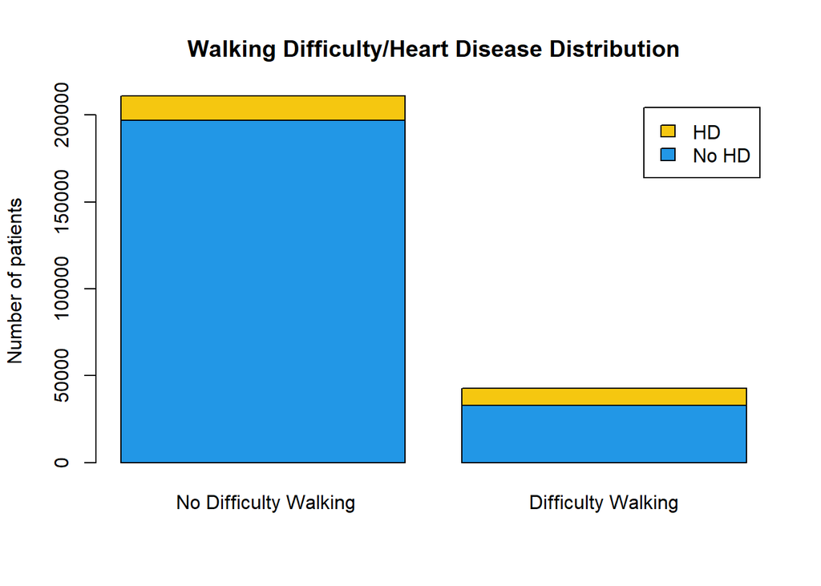

```r
walk <- xtabs(~HeartDiseaseorAttack+DiffWalk, data = hd)
rownames(walk) <- c("No HD", "HD")
colnames(walk) <- c(" No Difficulty Walking", "Difficulty Walking")

barplot(walk, legend.text = TRUE, main = "Walking Difficulty/Heart Disease Distribution", ylab = "Number of patients", col = c(4,7))
```

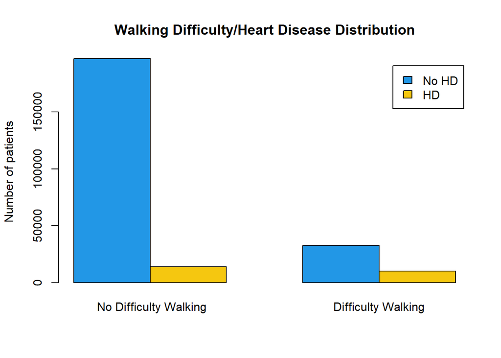

```r
barplot(walk, legend.text = TRUE, beside = TRUE, main = "Walking Difficulty/Heart Disease Distribution", ylab = "Number of patients", col = c(4,7))
```

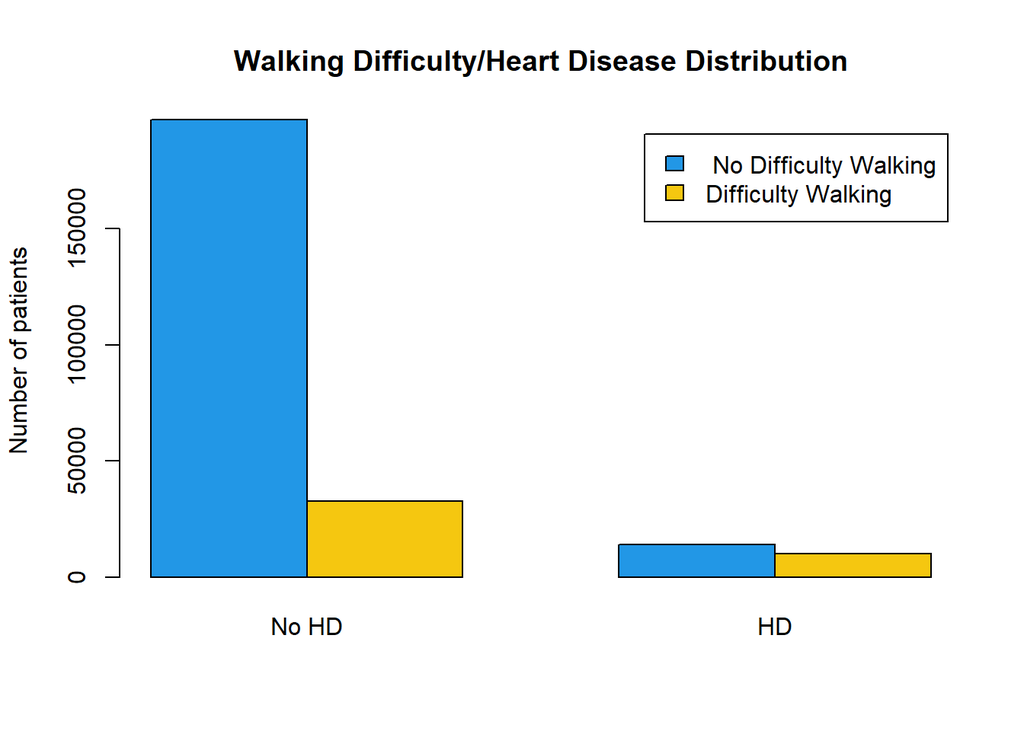

```r
barplot(t(walk), legend.text = TRUE, beside = TRUE, main = "Walking Difficulty/Heart Disease Distribution", ylab = "Number of patients", col = c(4,7))
```

```r
walk_percentage <- prop.table(walk,margin =1)[2,]
walk_percentage
```

```
##  No Difficulty Walking     Difficulty Walking
##              0.5850249              0.4149751
```

```r
#41.49% of people who have heart disease have difficulty walking. This is very substantial, even if it isn't a majority.

walk_odds = walk
walk_odds=rbind(walk_odds, 'Odds'=round(walk_odds[2,]/walk_odds[1,],2))
walk_odds=rbind(walk_odds, 'Odds Ratio'=c(0,round(walk_odds[3,2]/walk_odds[3,1],2)))

#People that have difficulty walking are 4.29x times more likely to have heart problems.

cat_vars["DiffWalk"] = 4.29
```

## Sex

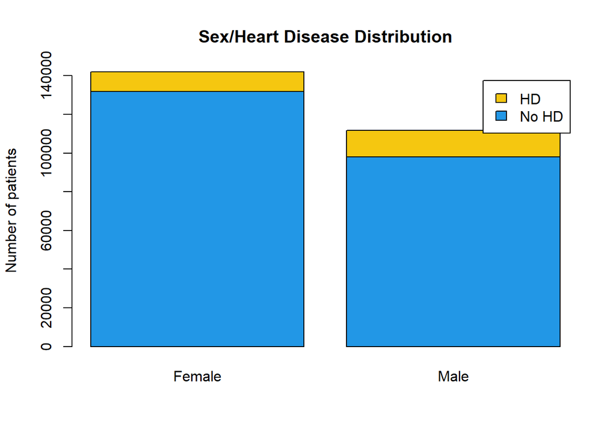

```r
sex <- xtabs(~HeartDiseaseorAttack+Sex, data = hd)
rownames(sex) <- c("No HD", "HD")
colnames(sex) <- c("Female", "Male")

barplot(sex, legend.text = TRUE, main = "Sex/Heart Disease Distribution", ylab = "Number of patients", col = c(4,7))
```

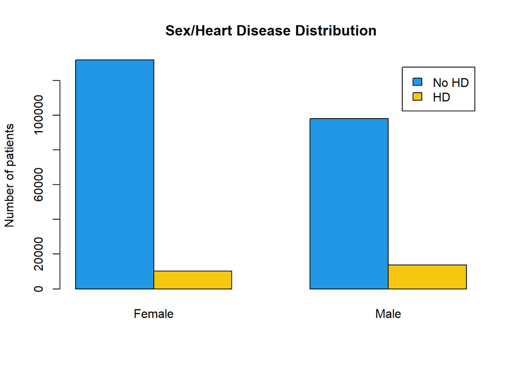

```r
barplot(sex, legend.text = TRUE, beside = TRUE, main = "Sex/Heart Disease Distribution", ylab = "Number of patients", col = c(4,7))
```

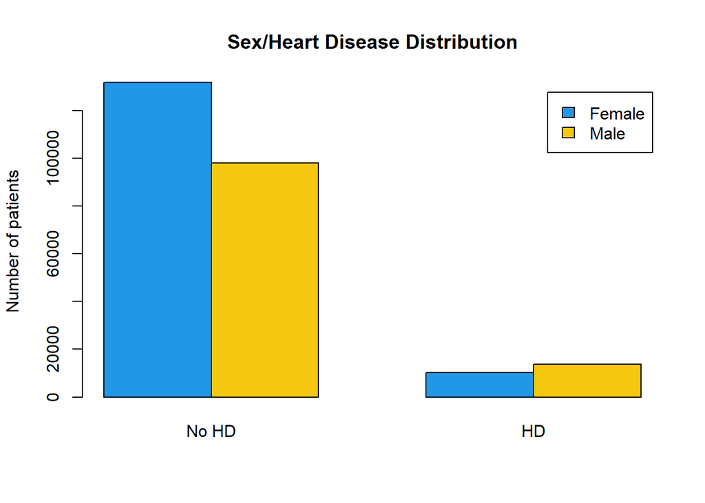

```r
barplot(t(sex), legend.text = TRUE, beside = TRUE, main = "Sex/Heart Disease Distribution", ylab = "Number of patients", col = c(4,7))
```

```r
sex_percentage <- prop.table(sex,margin =1)[2,]
sex_percentage
```

```
##    Female      Male
## 0.4271125 0.5728875
```

```r
#57.29% of people who have heart disease are Male.

sex_odds = sex
sex_odds=rbind(sex_odds, 'Odds'=round(sex_odds[2,]/sex_odds[1,],2))
sex_odds=rbind(sex_odds, 'Odds Ratio'=c(0,round(sex_odds[3,2]/sex_odds[3,1],2)))

#Males are 1.75x more likely to have heart problems than Females.

cat_vars["Sex"] = 1.75
```

## BMI

This one will be a little bit different as we are dealing with a continuous variable compared to the previous categorical variables.

BMI calculation; largely, based on the histogram, it appears that the distribution is similar. We can look at more exact values to see that the ratio of 1/10 is preserved. The basic breakdown of our data tells us that 229,787 polled participants do not have heart disease or have experienced a heart attack, while 23,893 have. Our second sample group is 10.40% of the larger sample group, and 9.42% of the total size. Therefore, if people with heart disease/attack are not disproportionately out of shape, each histogram bar should be 10% or less than the larger section.

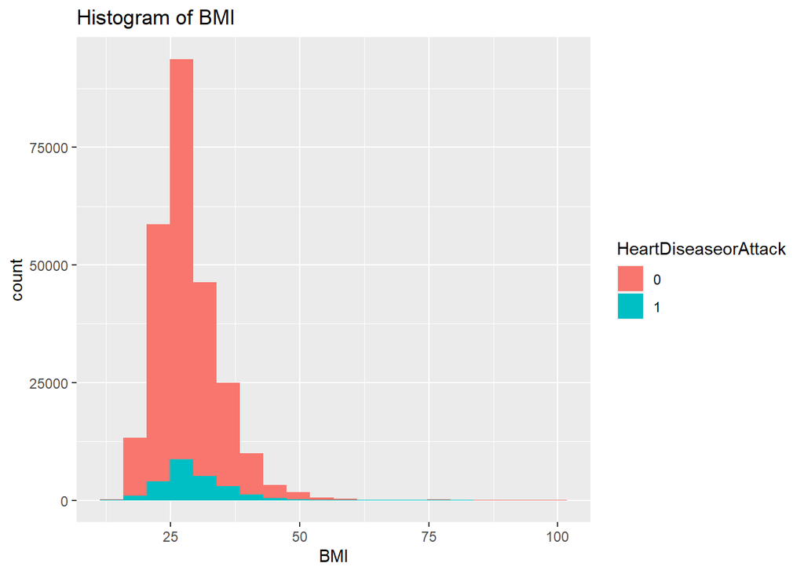

```r
ggplot(data=hd, aes(x=BMI,fill = HeartDiseaseorAttack)) +
  geom_histogram(bins=20,position='stack')+
  labs(x ='BMI', title ='Histogram of BMI')
```

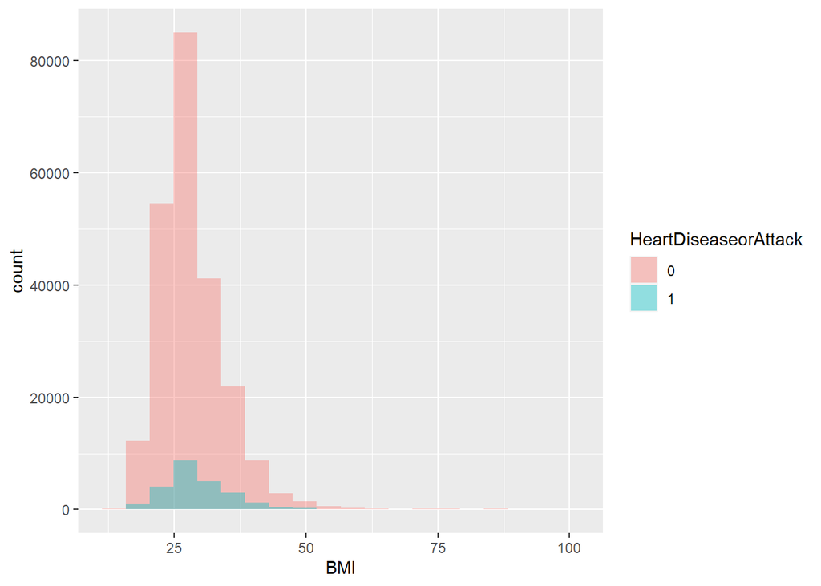

```r
# argument position = 'identity'. Don't adjust position
ggplot(data=hd, aes(x=BMI,fill = HeartDiseaseorAttack)) +
  geom_histogram(bins=20,position = "identity", alpha = 0.4)
```

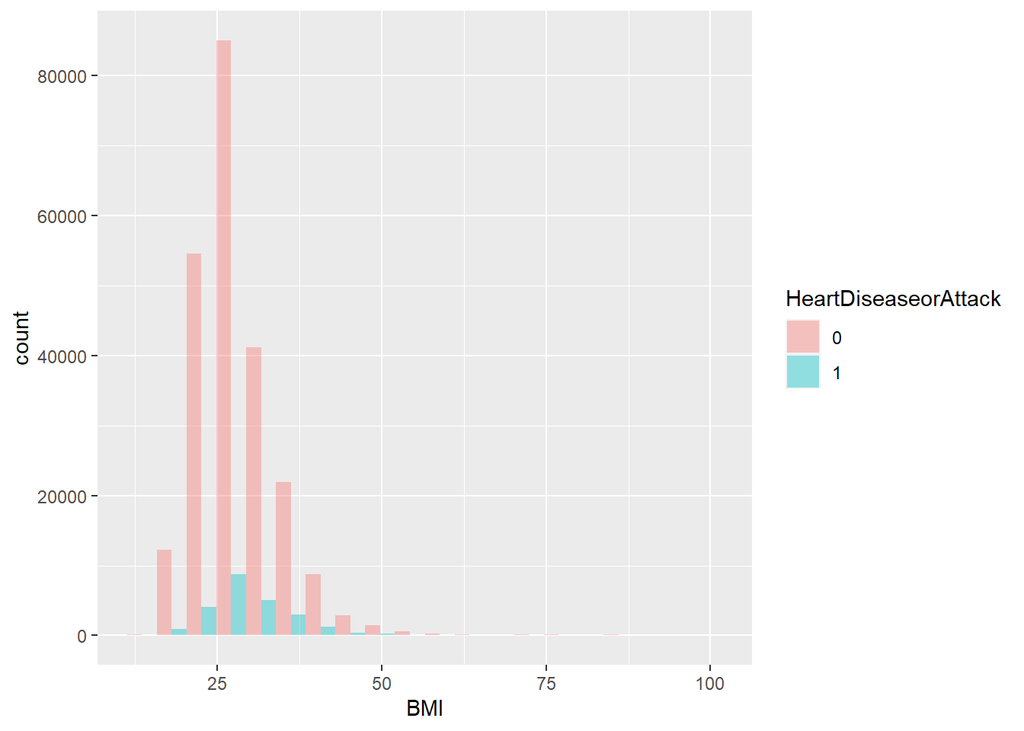

```r
# argument position = 'dodge'. Dodge overlapping objects side-to-side
ggplot(data=hd, aes(x=BMI,fill = HeartDiseaseorAttack)) +
  geom_histogram(bins=20,position = "dodge", alpha = 0.4)
```

```r
variable_name='BMI'
response_name='HeartDiseaseorAttack'
# create 10 break points for the following histograms
ax=seq(min(hd[,variable_name]),max(hd[,variable_name]),length.out=10)
# Save histogram data
hgA = hist(hd[hd[,response_name]==0,variable_name], breaks = ax, plot = FALSE)
hgB = hist(hd[hd[,response_name]==1,variable_name], breaks = ax, plot = FALSE)

table1=rbind('FALSE'=hgA$counts,'TRUE'=hgB$counts)
# The colname are break points of the histogram
# round the breaks to integers and simplify the results.
colnames(table1)=round(hgA$breaks[-1],0)
# add row sum
table1=cbind(table1, 'Total'=apply(table1,1,sum))
# add column sum
table1=rbind(table1, 'Total'=apply(table1,2,sum))
# add odds
table1=rbind(table1, 'Odds'=round(table1[2,]/table1[1,],2))
# print table
table1
```

```
##             22       31       41      50      60     69     79     88    98
## FALSE 21758.00 154272.0 43695.00 8138.00 1135.00 232.00 236.00 246.00 75.00
## TRUE   1519.00  15128.0  5829.00 1166.00  172.00  37.00  16.00  19.00  7.00
## Total 23277.00 169400.0 49524.00 9304.00 1307.00 269.00 252.00 265.00 82.00
## Odds      0.07      0.1     0.13    0.14    0.15   0.16   0.07   0.08  0.09
##          Total
## FALSE 229787.0
## TRUE   23893.0
## Total 253680.0
## Odds       0.1
```

Based on the odds ratio, the people most likely to have heart disease have BMIs at the 41-69 range. According to the CDC, if a BMI is higher than 30.0, a person is considered obese. Let’s extend out this sequence, and compare people from the healthy BMI range to people above 30.0.

```r
#Odds recalculation with 15 data points

ax=seq(min(hd[,variable_name]),max(hd[,variable_name]),length.out=25)
# Save histogram data
hgA = hist(hd[hd[,response_name]==0,variable_name], breaks = ax, plot = FALSE)
hgB = hist(hd[hd[,response_name]==1,variable_name], breaks = ax, plot = FALSE)

table1=rbind('FALSE'=hgA$counts,'TRUE'=hgB$counts)
# The colname are break points of the histogram
# round the breaks to integers and simplify the results.
colnames(table1)=round(hgA$breaks[-1],0)
# add row sum
table1=cbind(table1, 'Total'=apply(table1,1,sum))
# add column sum
table1=rbind(table1, 'Total'=apply(table1,2,sum))
# add odds
table1=rbind(table1, 'Odds'=round(table1[2,]/table1[1,],2))
# print table
table1
```

```
##           16      19       23       26       30       34       37      41
## FALSE 173.00 6304.00 28016.00 66919.00 50653.00 41180.00 18947.00 7533.00
## TRUE   27.00  591.00  1809.00  5949.00  5388.00  5090.00  2589.00 1033.00
## Total 200.00 6895.00 29825.00 72868.00 56041.00 46270.00 21536.00 8566.00
## Odds    0.16    0.09     0.06     0.09     0.11     0.12     0.14    0.14
##            44      48      51     55     59     62    66    69    73     76
## FALSE 5111.00 1924.00 1326.00 632.00 232.00 173.00 66.00 41.00 72.00 112.00
## TRUE   730.00  267.00  199.00 102.00  34.00  22.00 11.00 10.00  6.00   6.00
## Total 5841.00 2191.00 1525.00 734.00 266.00 195.00 77.00 51.00 78.00 118.00
## Odds     0.14    0.14    0.15   0.16   0.15   0.13  0.17  0.24  0.08   0.05
##           80    84     87    91   94    98    Total
## FALSE 114.00 78.00 104.00 30.00 30.0 17.00 229787.0
## TRUE   10.00 10.00   3.00  1.00  3.0  3.00  23893.0
## Total 124.00 88.00 107.00 31.00 33.0 20.00 253680.0
## Odds    0.09  0.13   0.03  0.03  0.1  0.18      0.1
```

```r
highbmi_false <- 41180.00 + 18947.00 + 7533.00 + 5111.00 + 1924.00 + 1326.00 + 632.00 + 232.00 + 173.00 + 66.00 + 41.00 + 72.00 + 112.00 + 114.00 + 78.00 + 104.00 + 30.00 + 30.0 + 17.00
lowbmi_false <- 173.00 + 6304.00 + 28016.00 + 66919.00 + 50653.00
lowbmi_true <- 27.00 + 591.00 + 1809.00 + 5949.00 + 5388.00
highbmi_true <- 5090.00 + 2589.00 + 1033.00 + 730.00 + 267.00 + 199.00 + 102.00 + 34.00 + 22.00 + 11.00 + 10.00 + 6.00 +  6.00 + 10.00 + 10.00  + 3.00 + 1.00 + 3.0 + 3.00

bmi_chart <- data.frame(matrix(ncol = 2, nrow = 2))
bmi_chart[1,1] = lowbmi_false
bmi_chart[1,2] = highbmi_false
bmi_chart[2,1] = lowbmi_true
bmi_chart[2,2] = highbmi_true
rownames(bmi_chart) = c("FALSE", "TRUE")
colnames(bmi_chart) = c("Low BMI", "High BMI")


bmi_odds = bmi_chart
bmi_odds=rbind(bmi_odds, 'Odds'=round(bmi_odds[2,]/bmi_odds[1,],2))
bmi_odds=rbind(bmi_odds, 'Odds Ratio'=c(0,round(bmi_odds[3,2]/bmi_odds[3,1],2)))
cat_vars["BMI"] = 1.44
```

People in the high BMI range are 1.44x more likely to have heart problems than people with a normal BMI range.

## General Health

People rated their general health out of 5. Given that this is another self-rating statistic, there is going to be some inherent bias.

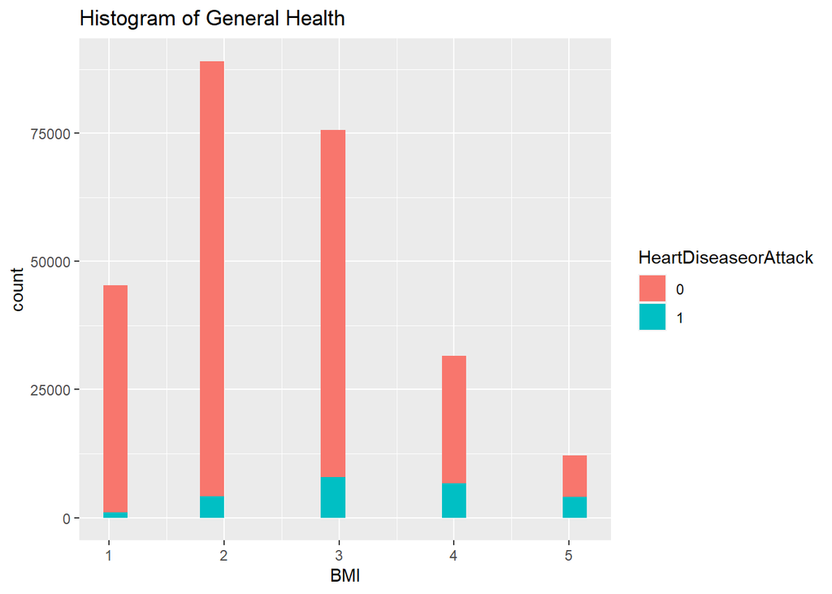

```r
ggplot(data=hd, aes(x=GenHlth,fill = HeartDiseaseorAttack)) +
  geom_histogram(bins=20,position='stack')+
  labs(x ='BMI', title ='Histogram of General Health')
```

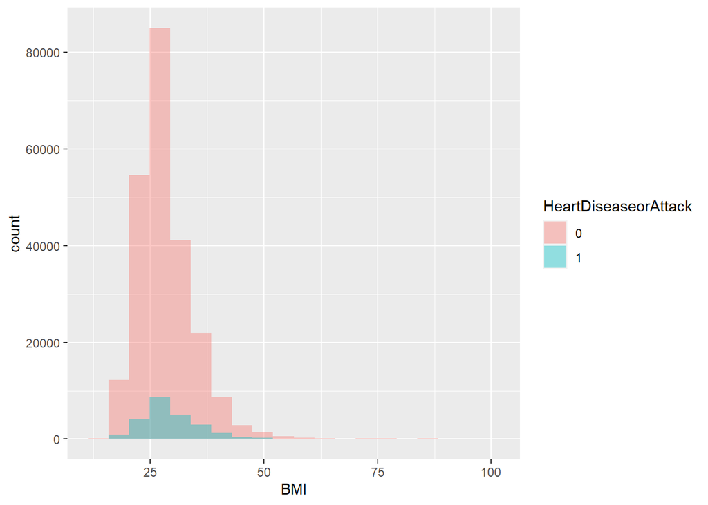

```r
# argument position = 'dodge'. Dodge overlapping objects side-to-side
ggplot(data=hd, aes(x=BMI,fill = HeartDiseaseorAttack)) +
  geom_histogram(bins=20,position = "identity", alpha = 0.4)
```

```r
health <- data.frame(matrix(ncol = 5, nrow = 2))
colnames(health) <- c(1:5)
rownames(health) <- c("FALSE", "TRUE")
health[1,1] = nrow(hd[(hd$GenHlth == 1 & hd$HeartDiseaseorAttack == 0),])
health[1,2] = nrow(hd[(hd$GenHlth == 2 & hd$HeartDiseaseorAttack == 0),])
health[1,3] = nrow(hd[(hd$GenHlth == 3 & hd$HeartDiseaseorAttack == 0),])
health[1,4] = nrow(hd[(hd$GenHlth == 4 & hd$HeartDiseaseorAttack == 0),])
health[1,5] = nrow(hd[(hd$GenHlth == 5 & hd$HeartDiseaseorAttack == 0),])
health[2,1] = nrow(hd[(hd$GenHlth == 1 & hd$HeartDiseaseorAttack == 1),])
health[2,2] = nrow(hd[(hd$GenHlth == 2 & hd$HeartDiseaseorAttack == 1),])
health[2,3] = nrow(hd[(hd$GenHlth == 3 & hd$HeartDiseaseorAttack == 1),])
health[2,4] = nrow(hd[(hd$GenHlth == 4 & hd$HeartDiseaseorAttack == 1),])
health[2,5] = nrow(hd[(hd$GenHlth == 5 & hd$HeartDiseaseorAttack == 1),])
health_odds = health
health_odds = rbind(health_odds, 'Odds'=round(health_odds[2,]/health_odds[1,],2))
health_odds
```

```
##              1        2        3        4       5
## FALSE 44283.00 84956.00 67732.00 24842.00 7974.00
## TRUE   1016.00  4128.00  7914.00  6728.00 4107.00
## Odds      0.02     0.05     0.12     0.27    0.52
```

Oddly, people that rate their general health as a 5 have by far the highest odd-ratio of having heart disease, while the people that rate their health as a 1 have the lowest odd-ratio. This is reinforced by the first histogram that we included, where the 5th bar can be clearly seen to have a large percentage.

## Mental Health

Mental Health - “Now thinking about your mental health, which includes stress, depression, and problems with emotions, for how many days during the past 30 days was your mental health not good?”

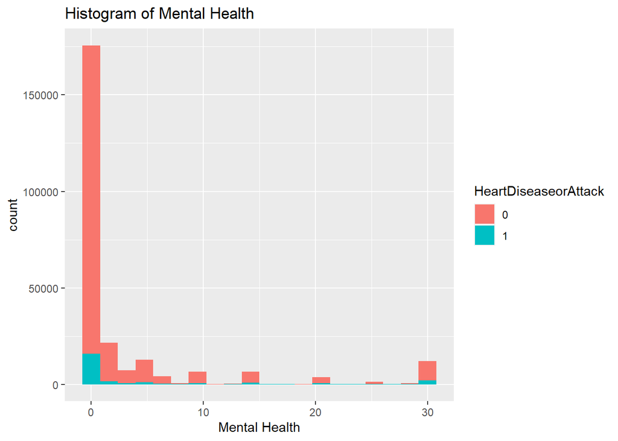

```r
ggplot(data=hd, aes(x=MentHlth,fill = HeartDiseaseorAttack)) +
  geom_histogram(bins=20,position='stack')+
  labs(x ='Mental Health', title ='Histogram of Mental Health')
```

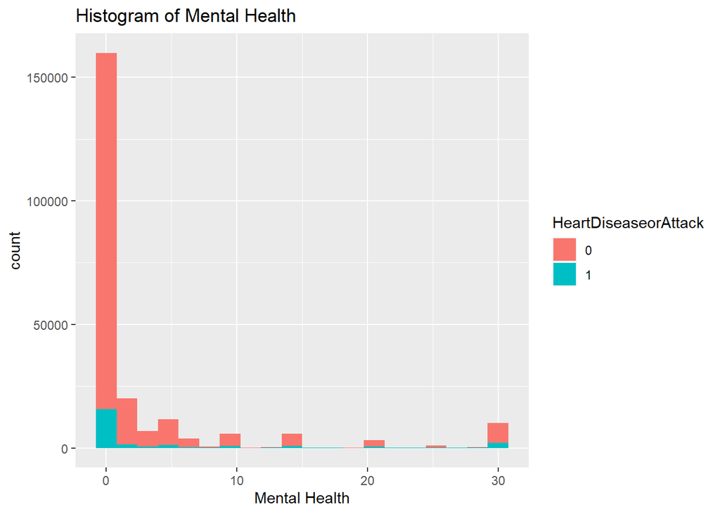

```r
ggplot(data=hd, aes(x=MentHlth,fill = HeartDiseaseorAttack)) +
  geom_histogram(bins=20,position='identity')+
  labs(x ='Mental Health', title ='Histogram of Mental Health')
```

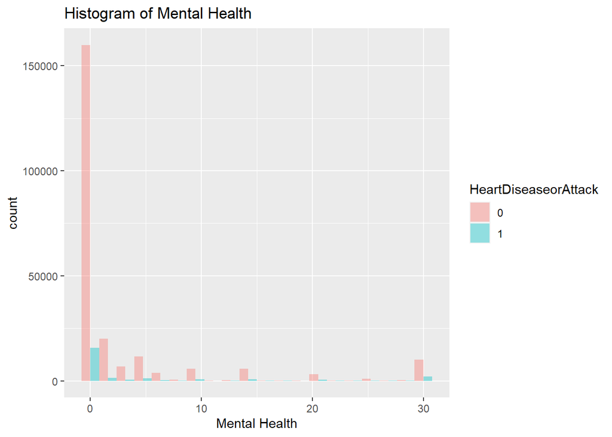

```r
# argument position = 'dodge'. Dodge overlapping objects side-to-side
ggplot(data=hd, aes(x=MentHlth,fill = HeartDiseaseorAttack)) +
  geom_histogram(bins=20,position = "dodge", alpha = 0.4) +
  labs(x ='Mental Health', title ='Histogram of Mental Health')
```

```r
variable_name='MentHlth'
response_name='HeartDiseaseorAttack'
# create 10 break points for the following histograms
ax=seq(min(hd[,variable_name]),max(hd[,variable_name]),length.out=10)
# Save histogram data
hgA = hist(hd[hd[,response_name]==0,variable_name], breaks = ax, plot = FALSE)
hgB = hist(hd[hd[,response_name]==1,variable_name], breaks = ax, plot = FALSE)

table3=rbind('FALSE'=hgA$counts,'TRUE'=hgB$counts)
# The colname are break points of the histogram
# round the breaks to integers and simplify the results.
colnames(table3)=round(hgA$breaks[-1],0)
# add row sum
table3=cbind(table3, 'Total'=apply(table3,1,sum))
# add column sum
table3=rbind(table3, 'Total'=apply(table3,2,sum))
# add odds
table3=rbind(table3, 'Odds'=round(table3[2,]/table3[1,],2))
# print table
table3
```

```
##              3       7       10     13      17      20     23      27      30
## FALSE 186802.0 12556.0  9164.00 423.00 5895.00 3037.00 277.00 1072.00 10561.0
## TRUE   17851.0  1251.0  1039.00  57.00  865.00  494.00  51.00  194.00  2091.0
## Total 204653.0 13807.0 10203.00 480.00 6760.00 3531.00 328.00 1266.00 12652.0
## Odds       0.1     0.1     0.11   0.13    0.15    0.16   0.18    0.18     0.2
##          Total
## FALSE 229787.0
## TRUE   23893.0
## Total 253680.0
## Odds       0.1
```

Unsurprisingly, people that report emotional problems 30 out of 30 days have the highest odds of having heart problems.

## Physical Health

Physical Health: “Now thinking about your physical health, which includes physical illness and injury, for how many days during the past 30 days was your physical health not good?”

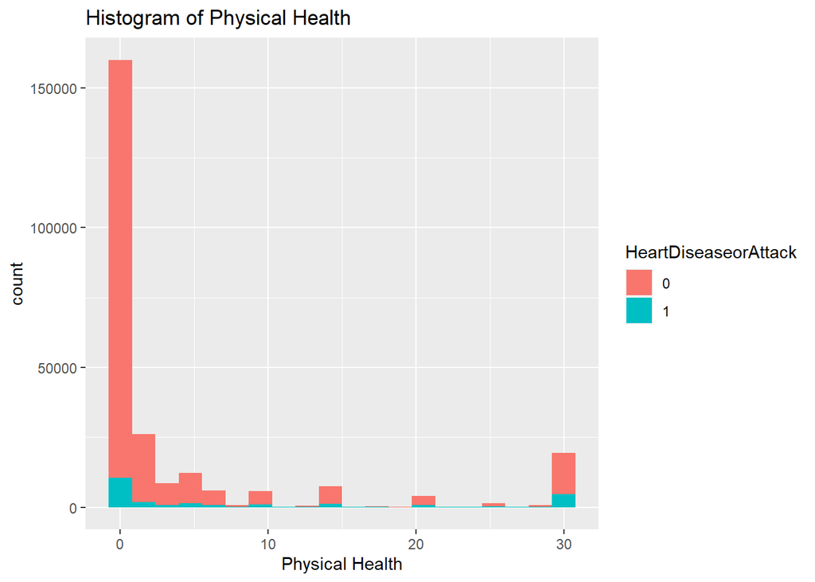

```r
ggplot(data=hd, aes(x=PhysHlth,fill = HeartDiseaseorAttack)) +
  geom_histogram(bins=20,position='stack')+
  labs(x ='Physical Health', title ='Histogram of Physical Health')
```

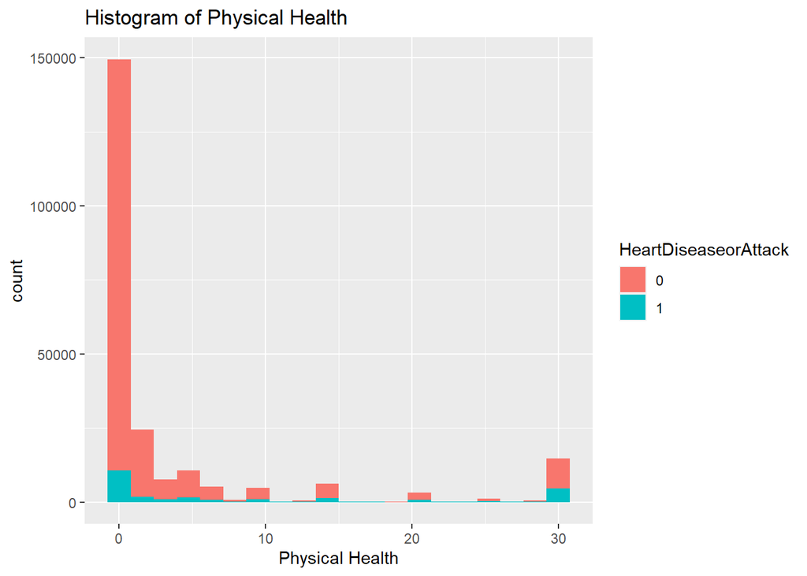

```r
ggplot(data=hd, aes(x=PhysHlth,fill = HeartDiseaseorAttack)) +
  geom_histogram(bins=20,position='identity')+
  labs(x ='Physical Health', title ='Histogram of Physical Health')
```

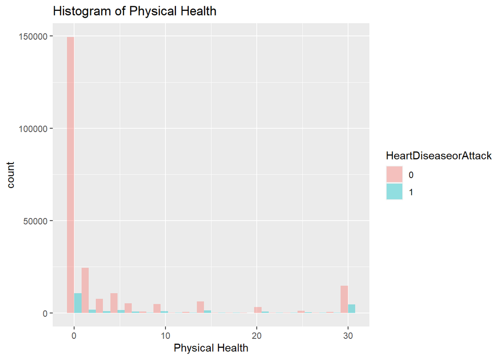

```r
# arguPhys position = 'dodge'. Dodge overlapping objects side-to-side
ggplot(data=hd, aes(x=PhysHlth,fill = HeartDiseaseorAttack)) +
  geom_histogram(bins=20,position = "dodge", alpha = 0.4) +
  labs(x ='Physical Health', title ='Histogram of Physical Health')
```

```r
variable_name='PhysHlth'
response_name='HeartDiseaseorAttack'
# create 10 break points for the following histograms
ax=seq(min(hd[,variable_name]),max(hd[,variable_name]),length.out=10)
# Save histogram data
hgA = hist(hd[hd[,response_name]==0,variable_name], breaks = ax, plot = FALSE)
hgB = hist(hd[hd[,response_name]==1,variable_name], breaks = ax, plot = FALSE)

table3=rbind('FALSE'=hgA$counts,'TRUE'=hgB$counts)
# The colname are break points of the histogram
# round the breaks to integers and simplify the results.
colnames(table3)=round(hgA$breaks[-1],0)
# add row sum
table3=cbind(table3, 'Total'=apply(table3,1,sum))
# add column sum
table3=rbind(table3, 'Total'=apply(table3,2,sum))
# add odds
table3=rbind(table3, 'Odds'=round(table3[2,]/table3[1,],2))
# print table
table3
```

```
##               3        7       10    13      17      20     23      27       30
## FALSE 181532.00 11828.00  9525.00 590.0 6293.00 2811.00 665.00 1151.00 15392.00
## TRUE   13167.00  1666.00  1596.00 116.0 1322.00  732.00 124.00  326.00  4844.00
## Total 194699.00 13494.00 11121.00 706.0 7615.00 3543.00 789.00 1477.00 20236.00
## Odds       0.07     0.14     0.17   0.2    0.21    0.26   0.19    0.28     0.31
##          Total
## FALSE 229787.0
## TRUE   23893.0
## Total 253680.0
## Odds       0.1
```

Unsurprisingly, the people with the highest odds of heart problems report physical problems every day out of the month.

## Age

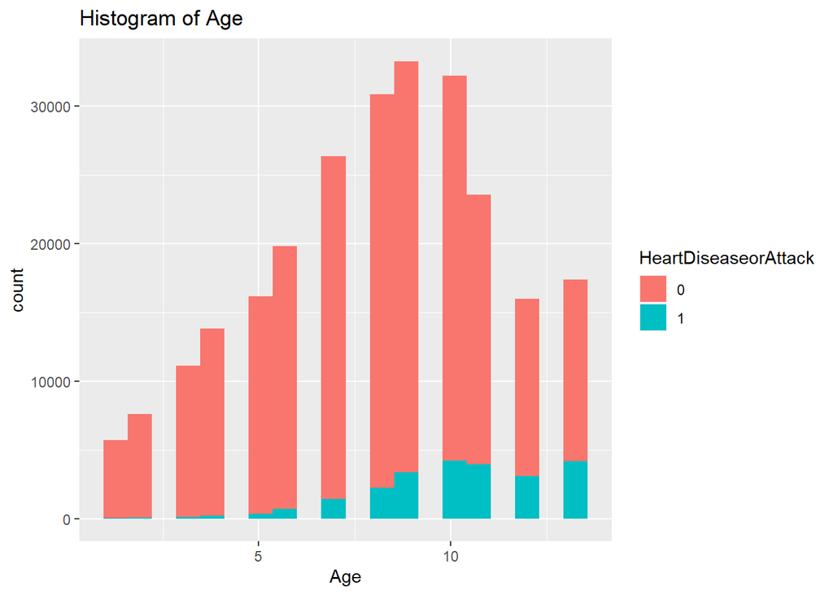

```r
ggplot(data=hd, aes(x=Age,fill = HeartDiseaseorAttack)) +
  geom_histogram(bins=20,position='stack')+
  labs(x ='Age', title ='Histogram of Age')
```

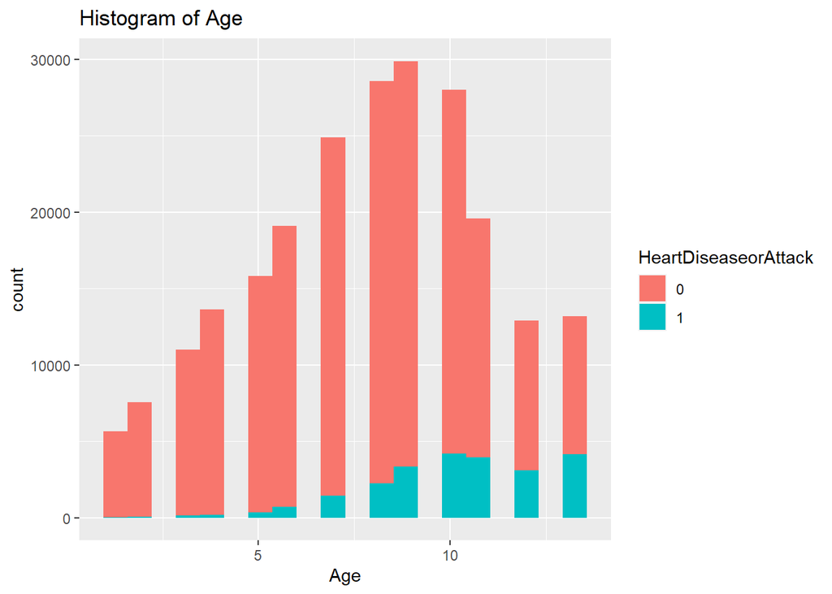

```r
ggplot(data=hd, aes(x=Age,fill = HeartDiseaseorAttack)) +
  geom_histogram(bins=20,position='identity')+
  labs(x ='Age', title ='Histogram of Age')
```

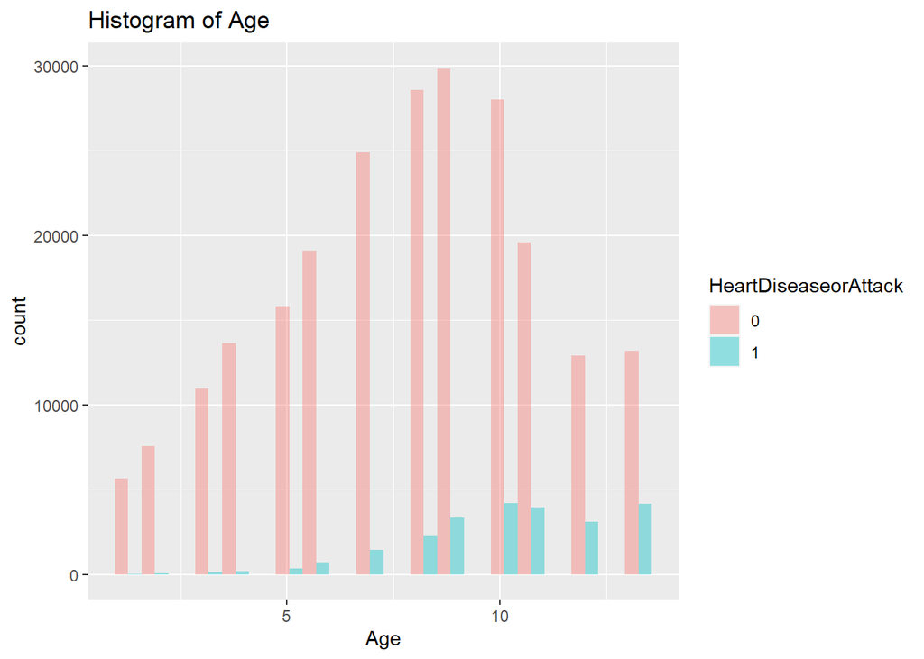

```r
ggplot(data=hd, aes(x=Age,fill = HeartDiseaseorAttack)) +
  geom_histogram(bins=20,position = "dodge", alpha = 0.4) +
  labs(x ='Age', title ='Histogram of Age')
```

```r
variable_name='Age'
response_name='HeartDiseaseorAttack'

#We'll use 14 stacks for the 14 different categories.
ax=seq(min(hd[,variable_name]),max(hd[,variable_name]),length.out=13)
# Save histogram data
hgA = hist(hd[hd[,response_name]==0,variable_name], breaks = ax, plot = FALSE)
hgB = hist(hd[hd[,response_name]==1,variable_name], breaks = ax, plot = FALSE)

table3=rbind('FALSE'=hgA$counts,'TRUE'=hgB$counts)
# The colname are break points of the histogram
# round the breaks to integers and simplify the results.
colnames(table3)=round(hgA$breaks[-1],0)
# add row sum
table3=cbind(table3, 'Total'=apply(table3,1,sum))
# add column sum
table3=rbind(table3, 'Total'=apply(table3,2,sum))
# add odds
table3=rbind(table3, 'Odds'=round(table3[2,]/table3[1,],2))
# print table
table3
```

```
##              2        3        4        5        6        7        8        9
## FALSE 13215.00 10997.00 13630.00 15806.00 19107.00 24889.00 28579.00 29886.00
## TRUE     83.00   126.00   193.00   351.00   712.00  1425.00  2253.00  3358.00
## Total 13298.00 11123.00 13823.00 16157.00 19819.00 26314.00 30832.00 33244.00
## Odds      0.01     0.01     0.01     0.02     0.04     0.06     0.08     0.11
##             10      11       12       13    Total
## FALSE 28001.00 19586.0 12887.00 13204.00 229787.0
## TRUE   4193.00  3947.0  3093.00  4159.00  23893.0
## Total 32194.00 23533.0 15980.00 17363.00 253680.0
## Odds      0.15     0.2     0.24     0.31      0.1
```

The people in the oldest age categories have by far the highest odds out of full age range. The first 4 categories have very little people with heart problems, and it steadily escalates until it reaches Category 6 and breaks into exponential growth before plateauing to the 3000-4000 from 9-14.

## Education

Education is the highest grade of education a patient has reached.

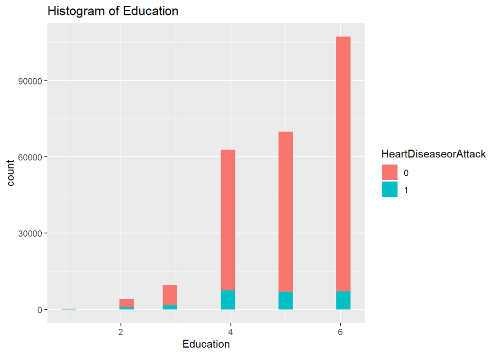

```r
ggplot(data=hd, aes(x=Education,fill = HeartDiseaseorAttack)) +
  geom_histogram(bins=20,position='stack')+
  labs(x ='Education', title ='Histogram of Education')
```

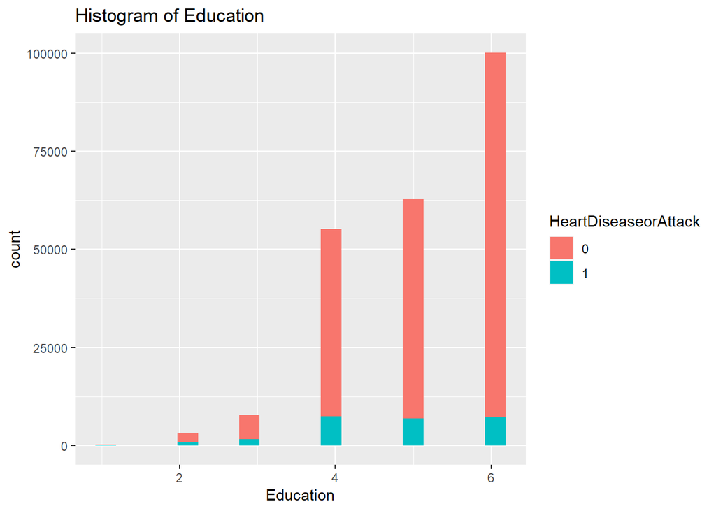

```r
ggplot(data=hd, aes(x=Education,fill = HeartDiseaseorAttack)) +
  geom_histogram(bins=20,position='identity')+
  labs(x ='Education', title ='Histogram of Education')
```

[figure not shown]

```r
ggplot(data=hd, aes(x=Age,fill = HeartDiseaseorAttack)) +
  geom_histogram(bins=20,position = "dodge", alpha = 0.4) +
  labs(x ='Education', title ='Histogram of Education')
```

```r
variable_name='Education'
response_name='HeartDiseaseorAttack'

ax=seq(min(hd[,variable_name]),max(hd[,variable_name]),length.out=5)
# Save histogram data
hgA = hist(hd[hd[,response_name]==0,variable_name], breaks = ax, plot = FALSE)
hgB = hist(hd[hd[,response_name]==1,variable_name], breaks = ax, plot = FALSE)

table3=rbind('FALSE'=hgA$counts,'TRUE'=hgB$counts)
# The colname are break points of the histogram
# round the breaks to integers and simplify the results.
colnames(table3)=round(hgA$breaks[-1],0)
# add row sum
table3=cbind(table3, 'Total'=apply(table3,1,sum))
# add column sum
table3=rbind(table3, 'Total'=apply(table3,2,sum))
# add odds
table3=rbind(table3, 'Odds'=round(table3[2,]/table3[1,],2))
# print table
table3
```

```
##             2       4        5         6    Total
## FALSE 3410.00 7860.00 55283.00 163234.00 229787.0
## TRUE   807.00 1618.00  7467.00  14001.00  23893.0
## Total 4217.00 9478.00 62750.00 177235.00 253680.0
## Odds     0.24    0.21     0.14      0.09      0.1
```

For people with lower education, they are more likely to have heart problems.

## Income

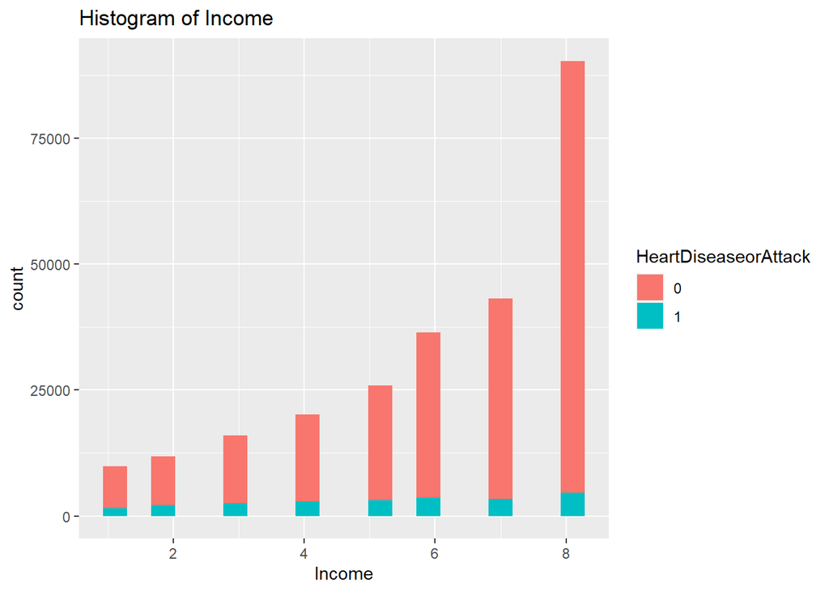

```r
ggplot(data=hd, aes(x=Income,fill = HeartDiseaseorAttack)) +
  geom_histogram(bins=20,position='stack')+
  labs(x ='Income', title ='Histogram of Income')
```

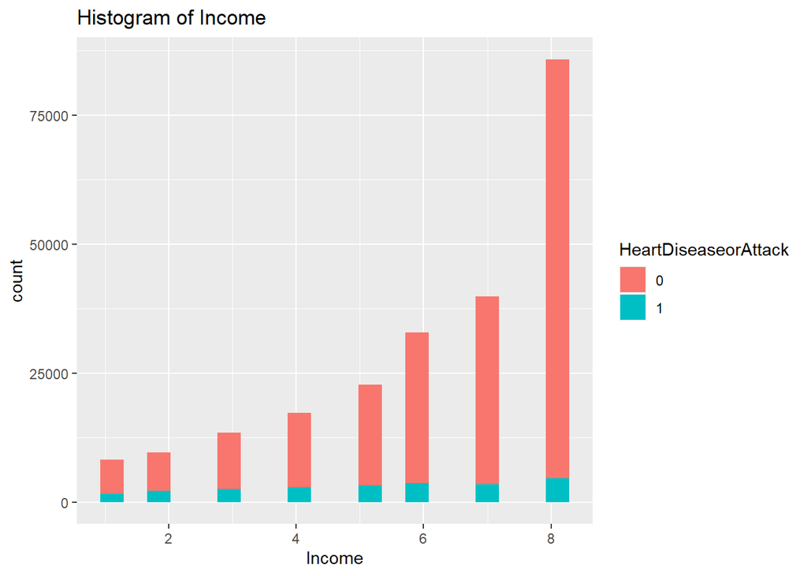

```r
ggplot(data=hd, aes(x=Income,fill = HeartDiseaseorAttack)) +
  geom_histogram(bins=20,position='identity')+
  labs(x ='Income', title ='Histogram of Income')
```

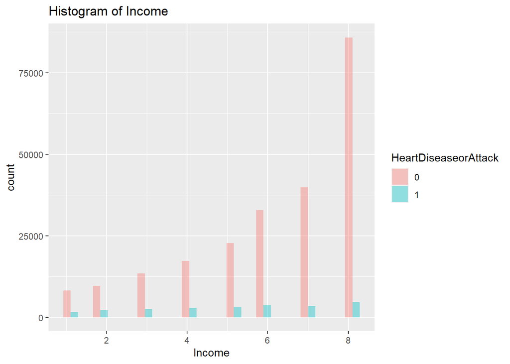

```r
ggplot(data=hd, aes(x=Income,fill = HeartDiseaseorAttack)) +
  geom_histogram(bins=20,position = "dodge", alpha = 0.4) +
  labs(x ='Income', title ='Histogram of Income')
```

```r
variable_name='Income'
response_name='HeartDiseaseorAttack'

ax=seq(min(hd[,variable_name]),max(hd[,variable_name]),length.out=8)
# Save histogram data
hgA = hist(hd[hd[,response_name]==0,variable_name], breaks = ax, plot = FALSE)
hgB = hist(hd[hd[,response_name]==1,variable_name], breaks = ax, plot = FALSE)

table3=rbind('FALSE'=hgA$counts,'TRUE'=hgB$counts)
# The colname are break points of the histogram
# round the breaks to integers and simplify the results.
colnames(table3)=round(hgA$breaks[-1],0)
# add row sum
table3=cbind(table3, 'Total'=apply(table3,1,sum))
# add column sum
table3=rbind(table3, 'Total'=apply(table3,2,sum))
# add odds
table3=rbind(table3, 'Odds'=round(table3[2,]/table3[1,],2))
# print table
table3
```

```
##              2        3        4        5        6        7        8    Total
## FALSE 17844.00 13475.00 17307.00 22722.00 32824.00 39815.00 85800.00 229787.0
## TRUE   3750.00  2519.00  2828.00  3161.00  3646.00  3404.00  4585.00  23893.0
## Total 21594.00 15994.00 20135.00 25883.00 36470.00 43219.00 90385.00 253680.0
## Odds      0.21     0.19     0.16     0.14     0.11     0.09     0.05      0.1
```

Lower income patients have 4x more likelihood to have heart disease than people in the highest income bracket.

# Summary

```r
cat_vars
```

```
##                 HeartDiseaseorAttack HighBP HighChol Smoker Stroke PhysActivity
## Odd Ratio of HD                   NA      5      3.6   2.14   6.89         1.78
##                 Fruits Veggies HvyAlcoholConsump AnyHealthcare NoDocbcCost
## Odd Ratio of HD    1.1     1.3              1.83          1.38         1.4
##                 DiffWalk  Sex Diabetes PreDiabetes  BMI
## Odd Ratio of HD     4.29 1.75     3.62        2.12 1.44
```

Although it is more difficult to compare the continuous variables to the categorical variables, we can make assess some of the leading factors for heart disease and heart attacks.

Amongst the categorical variables, the leading factors are past Stroke - 6.89x, High Blood Pressure - 5.0x, Difficulty Walking - 4.29x, Diabetes - 3.62x, and High Cholesterol - 3.6x.

Variables like Fruits, Veggies, Heavy Alcohol Consumption, Sex, and BMI are not as big of factors.

When looking at the outer extremes of categorical variables like Income and Education, the odds of heart disease are much less for people with higher ranking levels.